# Sahadeo_Lab5

Rishi Sahadeo

2025-04-03

# Use the random sample with 200 movies you had from homework 4 to develop:

### 1.The confidence interval of the average global box office earning of all movies from 1980 to 2018

```r
set.seed(12345)

boxoffice <- read_csv("C:/Users/supaq/OneDrive/Desktop/Rutgers Courses/Statistical Inference for Data Science/Lab 4/movie_boxoffice-1.csv")
colnames(boxoffice)
```

```
## [1] "Movie"           "Month"           "Day"             "Year"
## [5] "Budget"          "Domestic_Gross"  "Worldwide_Gross"
```

Filter the population

```r
sample_200 <- boxoffice %>%
  filter(Year >= 1980, Year <= 2018) %>%
  sample_n(size = 200)

nrow(sample_200)
```

```
## [1] 200
```

```r
sample_200
```

```
## # A tibble: 200 × 7
##    Movie                 Month   Day  Year Budget Domestic_Gross Worldwide_Gross
##    <chr>                 <chr> <dbl> <dbl>  <dbl>          <dbl>           <dbl>
##  1 Dragonslayer          Jun      26  1981   18            6               6
##  2 Wag the Dog           Dec      25  1997   15           43.1            64.3
##  3 Turbulence            Jan      10  1997   55           11.5            11.5
##  4 Severance             May      18  2007   10            0.137           5.95
##  5 Diary of a Wimpy Kid… May      19  2017   22           20.7            35.4
##  6 Beavis and Butt-Head… Dec      20  1996   12           63.1            63.1
##  7 Walk the Line         Nov      18  2005   29          120.            188.
##  8 Mondays in the Sun    Jul      25  2003    4            0.146           0.146
##  9 The Best Little Whor… Jul      23  1982   20.5         69.7            69.7
## 10 The Bone Collector    Nov       5  1999   48           66.5           151.
## # ℹ 190 more rows
```

Create bootstrap distribution

```r
bootstrap_dist <- sample_200 %>%
  specify(response = Worldwide_Gross) %>%
  generate(reps = 1000, type = "bootstrap") %>%
  calculate(stat = "mean")
```

Visualize The Distribution

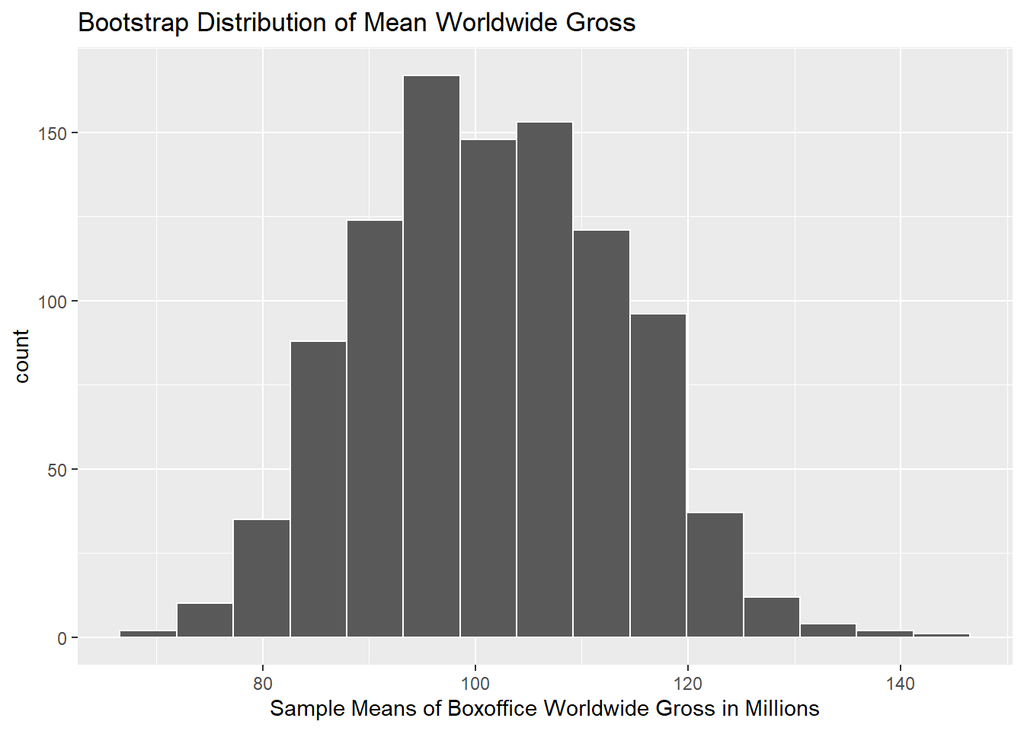

```r
visualize(bootstrap_dist) +
  labs(title = "Bootstrap Distribution of Mean Worldwide Gross",
       x = "Sample Means of Boxoffice Worldwide Gross in Millions")
```

The bootstrap distribution of the sample means of Worldwide_Gross is approximately symmetric and bell shaped. There is no skewness or presence of extreme outliers. With a normal distribution and a large sample size the sampling distribution is suitable for standard error and theoretical inference. The percentile method is reliable regardless of distribution or sample size.

Percentile Confidence Interval

```r
percentile_ci <- bootstrap_dist %>%
  get_ci(level = 0.95, type = "percentile")

percentile_ci
```

```
## # A tibble: 1 × 2
##   lower_ci upper_ci
##      <dbl>    <dbl>
## 1     79.9     124.
```

Based on the percentile method we are 95% confident that the mean worldwide box office gross of all movies released between the years 1980 and 2018 lies between $79.9 million and $124 million

Standard Error Method

```r
point_est <- sample_200 %>%
  specify(response = Worldwide_Gross) %>%
  calculate(stat = "mean")

point_est
```

```
## Response: Worldwide_Gross (numeric)
## # A tibble: 1 × 1
##    stat
##   <dbl>
## 1  102.
```

```r
se_ci <- bootstrap_dist %>%
  get_ci(level = 0.95, type = "se", point_estimate = point_est)

se_ci
```

```
## # A tibble: 1 × 2
##   lower_ci upper_ci
##      <dbl>    <dbl>
## 1     78.5     125.
```

Based on the standard error method we are 95% confident that the mean worldwide box office gross of all movies released between the years 1980 and 2018 lies between $78.5 million and $125 million

Theoretical Method

```r
bootstrap_dist %>%
  summarize(mean = mean(stat),
            se = sd(stat),
            lower = mean - 1.96 * se,
            upper = mean + 1.96 * se)
```

```
## # A tibble: 1 × 4
##    mean    se lower upper
##   <dbl> <dbl> <dbl> <dbl>
## 1  101.  11.9  78.2  125.
```

Based on the theoretical method we are 95% confident that the mean worldwide box office gross of all movies released between the years 1980 and 2018 lies between $78.2 million and $125 million

### 2. The confidence interval of the difference of average global box office earnings between movies in the summer (June, July and August) and movies in the rest of the year

Create a new column for “Summer” and “Non Summer” months.

```r
sample_200_months <- sample_200 %>%
  mutate(season = if_else(Month %in% c("Jun", "Jul", "Aug"), "Summer",
                          "Non_summer"))
```

Bootstrap

```r
bootstrap_diff <- sample_200_months %>%
  specify(response = Worldwide_Gross, explanatory = season) %>%
  generate(reps = 1000, type = "bootstrap") %>%
  calculate(stat = "diff in means", order = c("Summer", "Non_summer"))
```

Visualize the distribution

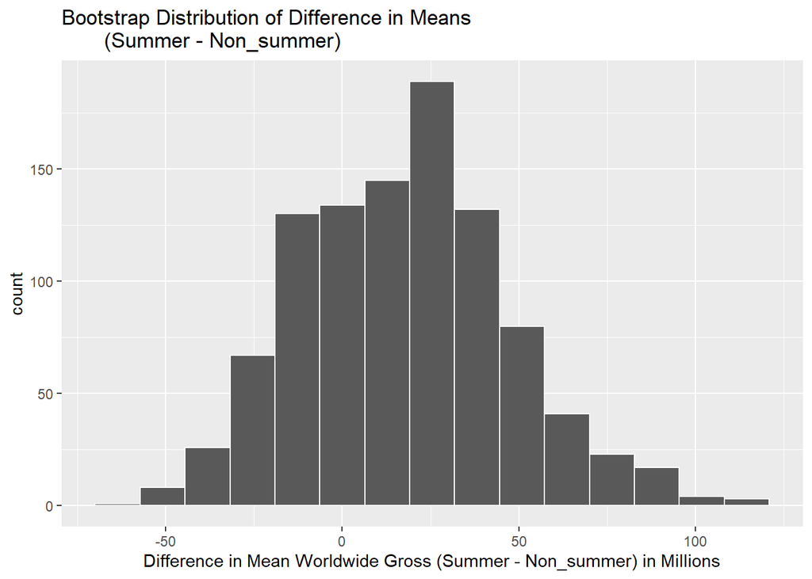

```r
visualize(bootstrap_diff) +
  labs(title = "Bootstrap Distribution of Difference in Means
       (Summer - Non_summer)",
       x = "Difference in Mean Worldwide Gross (Summer - Non_summer) in Millions")
```

The bootstrap distribution of the difference in mean (Summer - Non_summer) is not symmetric, and shows slight right skewness. Due to a large sample size the theoretical method is still a reliable method. However, since the distribution is skewed, the standard error method may have misleading results.

Percentile Confidence Interval Method

```r
percentile_ci_diff <- bootstrap_diff %>%
  get_ci(level = 0.95, type = "percentile")

percentile_ci_diff
```

```
## # A tibble: 1 × 2
##   lower_ci upper_ci
##      <dbl>    <dbl>
## 1    -34.2     82.0
```

Based on the percentile method, we are 95% confident that the true difference in average global box office earnings between summer and non summer movies lies between $-34.2 million and $82 million.

Standard Error Method

```r
point_est_diff <- sample_200_months %>%
  specify(response = Worldwide_Gross, explanatory = season) %>%
  calculate(stat = "diff in means", order = c("Summer", "Non_summer"))

point_est_diff
```

```
## Response: Worldwide_Gross (numeric)
## Explanatory: season (factor)
## # A tibble: 1 × 1
##    stat
##   <dbl>
## 1  18.1
```

```r
se_ci_diff <- bootstrap_diff %>%
  get_ci(level = 0.95, type = "se", point_estimate = point_est_diff)

se_ci_diff
```

```
## # A tibble: 1 × 2
##   lower_ci upper_ci
##      <dbl>    <dbl>
## 1    -39.4     75.6
```

Based on the standard error method we are 95% confident that the true difference in average global box office earnings between summer and non summer movies lies between -$39.4 million and $75.6 million

Theoretical CI Method

```r
bootstrap_diff %>%
  summarize(mean = mean(stat),
            se = sd(stat),
            lower = mean - 1.96 * se,
            upper = mean + 1.96 * se)
```

```
## # A tibble: 1 × 4
##    mean    se lower upper
##   <dbl> <dbl> <dbl> <dbl>
## 1  17.8  29.3 -39.7  75.3
```

Based on the theoretical method we are 95% confident that the true difference in average global box office earnings between movies released in the summer months and those released in the non summer months lies between -$39.7 and $75.3 million.

### 3. The confidence interval of the proportion of movies whose global box office earning exceeds budget.

Create column that checks is worldwide_gross > budget

```r
sample_200_budget <- sample_200 %>%
  mutate(profitable = Worldwide_Gross > Budget)
```

Bootstrap Distribution of proportions

```r
bootstrap_prop <- sample_200_budget %>%
  specify(response = profitable, success = "TRUE") %>%
  generate(reps = 1000, type = "bootstrap") %>%
  calculate(stat = "prop")
```

Visualize the Distribution

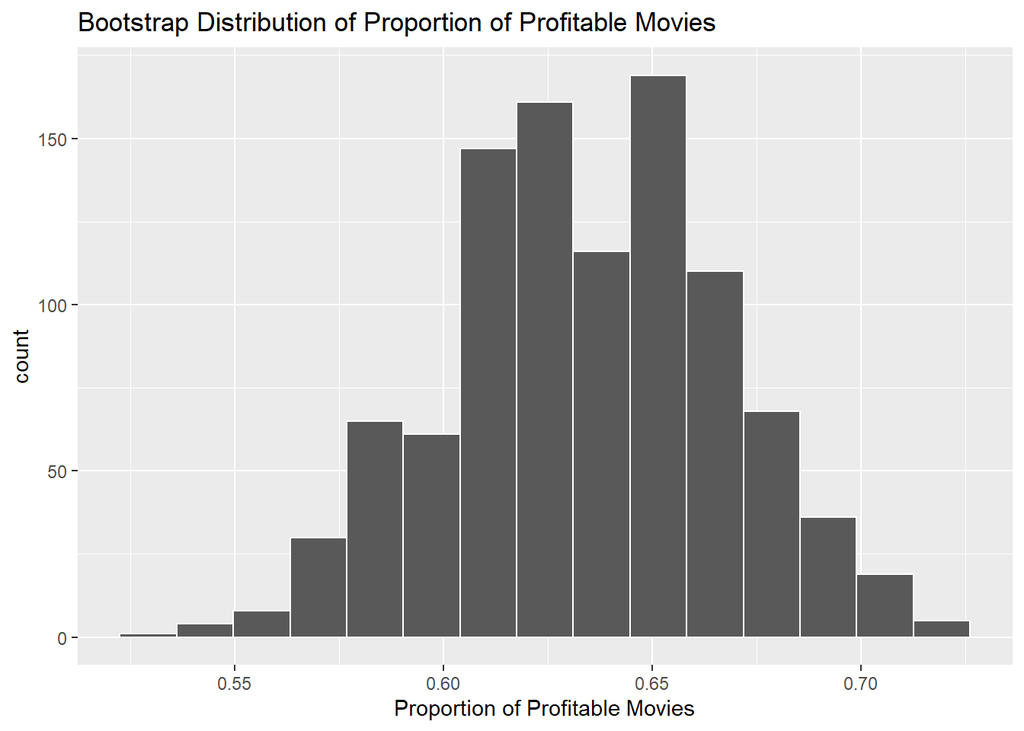

```r
visualize(bootstrap_prop) +
  labs(title = "Bootstrap Distribution of Proportion of Profitable Movies",
       x = "Proportion of Profitable Movies")
```

The bootstrap distribution of the proportion of profitable movies is slightly symmetric, and roughly bell-shaped. The distribution is not perfectly normal and does not show extreme skewness or outliers. Given the large sample size, n = 200, and the approximate symmetry, all three methods can be considered reliable for constructing a confidence interval.

Percentile Confidence Interval Method

```r
percentile_ci_prop <- bootstrap_prop %>%
  get_ci(level = 0.95, type = "percentile")

percentile_ci_prop
```

```
## # A tibble: 1 × 2
##   lower_ci upper_ci
##      <dbl>    <dbl>
## 1     0.57    0.695
```

Based on the percentile method we are 95% confident that between 57% and 69.5% of all movies released from 1980 to 2018 made more at the global box office than their budget.

Standard Error Method

```r
point_est_prop <- sample_200_budget %>%
  specify(response = profitable, success = "TRUE") %>%
  calculate(stat = "prop")

se_ci_prop <- bootstrap_prop %>%
  get_ci(level = 0.95, type = "se", point_estimate = point_est_prop)

se_ci_prop
```

```
## # A tibble: 1 × 2
##   lower_ci upper_ci
##      <dbl>    <dbl>
## 1    0.570    0.700
```

Based on the standard error method we are 95% confident that between 57% and 70% of all movies released from 1980 to 2018 made more at the global box office than their budget.

Theoretical Method

```r
bootstrap_prop %>%
  summarize(mean = mean(stat),
            se = sd(stat),
            lower = mean - 1.96 * se,
            upper = mean + 1.96 * se)
```

```
## # A tibble: 1 × 4
##    mean     se lower upper
##   <dbl>  <dbl> <dbl> <dbl>
## 1 0.634 0.0330 0.569 0.699
```

Based on the theoretical method, we are 95% confident that between 56.9% and 69.9% of all movies released from 1980 to 2018 made more at the global box office than their budget.

### 4. The confidence interval of the difference of proportions of movies whose global box office earning exceeds budget between movies released from 1980 to 1999 and those released from 2000 and 2018

New column that splits movies by release year group

```r
sample_200_group <- sample_200 %>%
  mutate(year_group = if_else(Year <= 1999, "1980_1999", "2000_2018"),
         profitable = Worldwide_Gross > Budget)
```

Bootstrap Distribution of difference in proportions

```r
bootstrap_diff_prop <- sample_200_group %>%
  specify(response = profitable, explanatory = year_group, success = "TRUE") %>%
  generate(reps = 1000, type = "bootstrap") %>%
  calculate(stat = "diff in props", order = c("1980_1999", "2000_2018"))
```

Visualize distribution

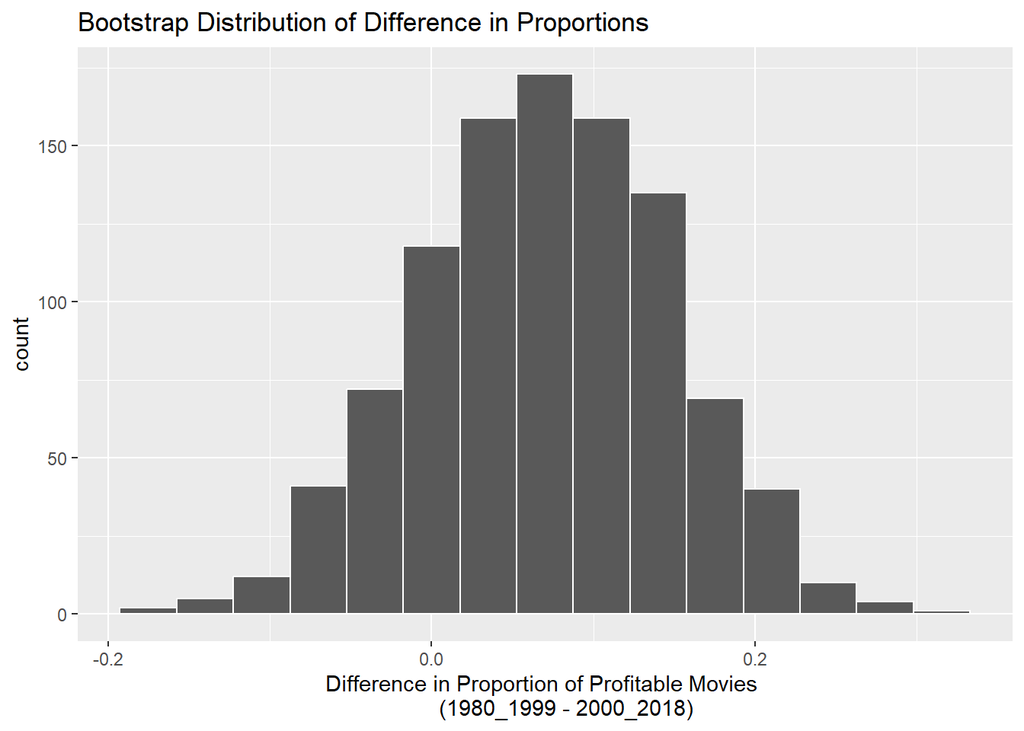

```r
visualize(bootstrap_diff_prop) +
  labs(title = "Bootstrap Distribution of Difference in Proportions",
       x = "Difference in Proportion of Profitable Movies
       (1980_1999 - 2000_2018)")
```

The bootstrap distribution of the difference in proportions (1980_1999 - 2000_2018) is approximately symmetric and bell shaped. This suggests the sampling distribution is suitable for standard error and theoretical inference.

Percentile CI Method

```r
percentile_ci_group <- bootstrap_diff_prop %>%
  get_ci(level = 0.95, type = "percentile")

percentile_ci_group
```

```
## # A tibble: 1 × 2
##   lower_ci upper_ci
##      <dbl>    <dbl>
## 1  -0.0808    0.214
```

Based on the percentile method we are 95% confident that the difference in the proportion of profitable movies between 1980-1999 and 2000-2018 lies between -8.08% and 21.4%

Standard Error Method

```r
point_est_group <- sample_200_group %>%
  specify(response = profitable, explanatory = year_group, success = "TRUE") %>%
  calculate(stat = "diff in props", order = c("1980_1999", "2000_2018"))

se_ci_group <- bootstrap_diff_prop %>%
  get_ci(level = 0.95, type = "se", point_estimate = point_est_group)

se_ci_group
```

```
## # A tibble: 1 × 2
##   lower_ci upper_ci
##      <dbl>    <dbl>
## 1  -0.0825    0.221
```

Based on the standard error method we are 95% confident that the difference in the proportion of profitable movies between 1980-1999 and 2000-2018 lies between -8.25% and 22.1%

Theoretical Method

```r
bootstrap_diff_prop %>%
  summarize(mean = mean(stat),
            se = sd(stat),
            lower = mean - 1.96 * se,
            upper = mean + 1.96 * se)
```

```
## # A tibble: 1 × 4
##     mean     se   lower upper
##    <dbl>  <dbl>   <dbl> <dbl>
## 1 0.0699 0.0773 -0.0817 0.221
```

Based on the theoretical method we are 95% confident that the difference in the proportion of profitable movies between 1980-1999 and 2000-2018 lies between -8.17% and 22.1%